# Il teorema di Gauss (Gauss's law)

Dimostrazione, simmetria, applicazioni

Fisica · 4A · mercoledì 30 settembre 2026

Punto di partenza

## Che cosa vogliamo sapere

Finora abbiamo descritto il **campo elettrico** (electric field) di una carica puntiforme, le sue **linee di forza** (field lines) e il **flusso** (flux) di un campo attraverso una superficie.

Quanto vale il flusso del campo elettrico attraverso una superficie chiusa? E dipende dalla forma della superficie?

Come procediamo

Strumento 1

## Strumento 1 · Il campo di una carica puntiforme

Una carica puntiforme Q genera a distanza r un campo di modulo

E=\frac{Q}{4\pi\varepsilon_0\,r^2}=k\,\frac{Q}{r^2}\qquad k=\frac{1}{4\pi\varepsilon_0}

con **ε<sub>0</sub>** = 8,85×10⁻¹² C²/(N·m²), la **permittività elettrica del vuoto** (vacuum permittivity).

- **Direzione:** radiale. **Verso:** uscente se Q > 0, entrante se Q < 0.
- **Modulo:** dipende solo da r: uguale su tutta una sfera centrata su Q.

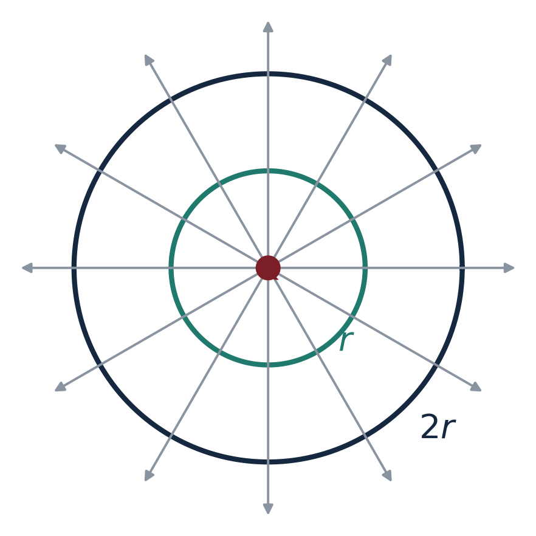

Strumento 2

## Strumento 2 · Il flusso di un pezzettino

Dividiamo la superficie in **pezzettini** così piccoli da essere piani, con E costante.

- **ΔS** (vettore superficie): modulo = area, direzione ⟂ al pezzettino, verso **uscente**.
- **θ**: angolo fra E e ΔS.

\Delta\Phi=\vec E\cdot\Delta\vec S=E\,\Delta S\cos\theta

Analogia: la pioggia su una finestra. Tanta se la finestra è di fronte alle gocce, nulla se è parallela.

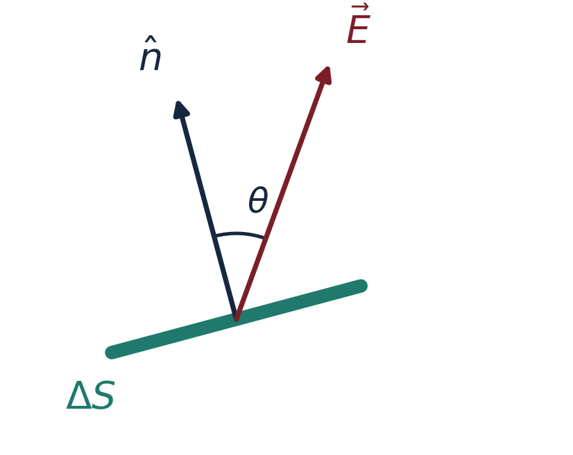

Provalo

## Il flusso di un pezzettino: θ e ΔS

Angolo θ**0°**

Area ΔS**2,0 m²**

Campo fisso: E = 5 N/C (freccia bordeaux). La normale uscente n è la freccia navy.

Strumento 3

## Strumento 3 · Il flusso attraverso una superficie chiusa

Una **superficie chiusa** (closed surface) Ω divide lo spazio in un dentro e un fuori. La dividiamo in n pezzettini ΔS<sub>i</sub>; in ognuno il campo è E<sub>i</sub>.

\Phi_\Omega(\vec E)=\sum_{i=1}^{n}\vec E_i\cdot\Delta\vec S_i

Il flusso vero è il limite per ΔS<sub>i</sub> → 0. Unità: N·m²/C.

Su una superficie qualunque il conto è difficile: E cambia in modulo e direzione.

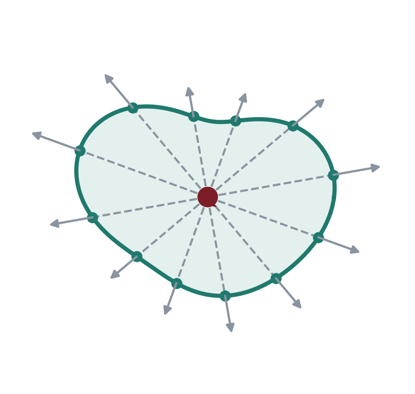

1

## Perché il flusso non dipende dalla forma

Dimostrazione in tre mosse

Il piano

## L'idea in tre mosse

Su una patata non sappiamo calcolare il flusso. Su una sfera con la carica al centro sì: si parte da lì.

1

Sfera con la carica al centro

qui il conto si fa: Φ = Q/ε<sub>0</sub>

2

Una forma qualunque

le linee di forza sono le stesse: il flusso non cambia

3

Carica fuori, più cariche

ogni linea che entra poi esce; i flussi si sommano

Il flusso conta le linee di forza che escono, non l'intensità del campo.

Mossa 1 (1/4)

## Mossa 1 · Sfera con la carica al centro: impostiamo

Sia Ω una sfera di raggio r con la carica Q **al centro**, divisa in n porzioni di aree ΔS<sub>1</sub>, …, ΔS<sub>n</sub>; su ciascuna il campo E<sub>i</sub> è praticamente costante.

**Osservazione 1.** Tutti i punti di Ω hanno la stessa distanza r da Q, quindi tutti i vettori E<sub>i</sub> hanno lo stesso modulo:

E_i=E=\frac{Q}{4\pi\varepsilon_0\,r^2}

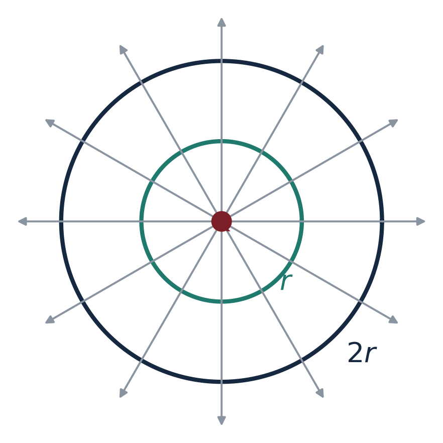

Mossa 1 (2/4)

## Mossa 1 · Il prodotto scalare diventa un prodotto

**Osservazione 2.** Su una sfera il campo è radiale, cioè perpendicolare alla superficie, come il vettore ΔS<sub>i</sub>. I due vettori sono paralleli e concordi (per Q > 0): θ<sub>i</sub> = 0 e cos θ<sub>i</sub> = 1.

\vec E_i\cdot\Delta\vec S_i=E_i\,\Delta S_i\cos 0=E\,\Delta S_i

Ogni addendo della somma è dunque **E ΔS<sub>i</sub>**, con lo stesso E in tutti.

Prossima slide: la somma.

Mossa 1 (3/4)

## Mossa 1 · Il flusso, uguaglianza per uguaglianza

Definizione di flusso e **proprietà distributiva** (raccoglimento a fattor comune):

\Phi_\Omega(\vec E)=\sum_{i=1}^{n}\vec E_i\cdot\Delta\vec S_i=\sum_{i=1}^{n}E\,\Delta S_i=E\sum_{i=1}^{n}\Delta S_i=\frac{Q}{4\pi\varepsilon_0\,r^2}\sum_{i=1}^{n}\Delta S_i

- **1ª** definizione di flusso
- **2ª** paralleli: prodotto dei moduli
- **3ª** E uguale in ogni addendo: si raccoglie
- **4ª** sostituiamo il valore di Coulomb

Mossa 1 (4/4)

## Mossa 1 · Il risultato: il raggio sparisce

La somma delle aree delle n porzioni è l'**area totale** della sfera:

\sum_{i=1}^{n}\Delta S_i=S_\Omega=4\pi r^2

\Phi_\Omega(\vec E)=\frac{Q}{4\pi\varepsilon_0\,r^2}\,S_\Omega=\frac{Q}{4\pi\varepsilon_0\,r^2}\cdot 4\pi r^2=\frac{Q}{\varepsilon_0}

Il 4πr² del numeratore semplifica il 4πr² del denominatore: il raggio non compare più.

Mossa 2 · qualunque forma

## Stesse linee, qualunque superficie

Da Q partono le linee di forza. Il flusso **conta quante ne escono** dalla superficie.

**Sfera:** escono 12 linee.

**Patata:** escono le stesse 12 linee.

Stesse linee, stesso flusso: Q/ε<sub>0</sub>.

[figure not shown]

Mossa 2 · l'inclinazione sparisce

## Una superficie a scalini

Ogni superficie si approssima a scalini: facce **perpendicolari** o **parallele** al campo.

[figure not shown]

Facce **parallele**: flusso 0. Facce **perpendicolari**: E·ΔS. Nessun coseno.

Mossa 2 · superfici che rientrano

## Se la superficie rientra

Una linea di forza può **uscire, rientrare e uscire di nuovo**.

+1\;-\;1\;+\;1\;=\;+1

Si contano uscite meno entrate: ogni linea vale 1.

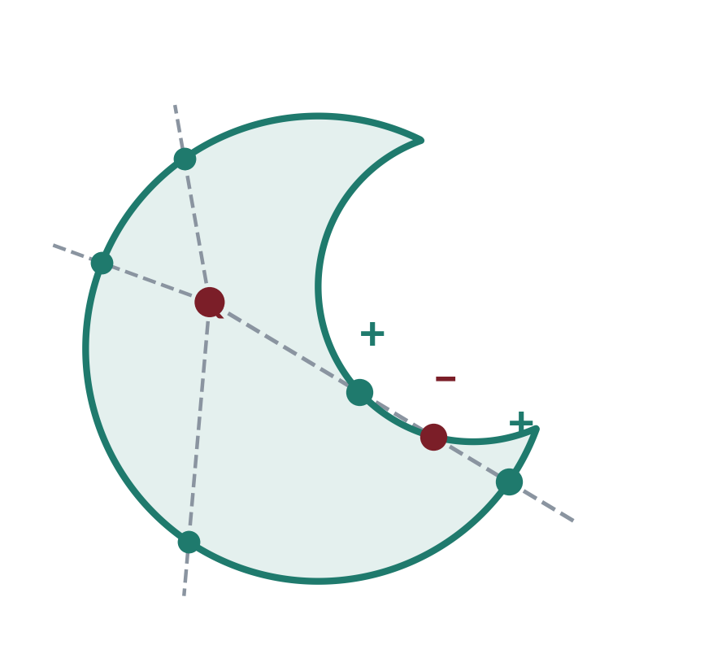

Mossa 3 · carica fuori

## Carica fuori dalla superficie

Ora Q sta **fuori** da Ω. Ogni linea che entra, prima o poi **esce**.

\text{carica esterna:}\quad \Phi=0

Tante linee entrano, tante escono: flusso zero.

[figure not shown]

Mossa 3 · più cariche

## Più cariche: sovrapposizione

Il campo di più cariche è la **somma vettoriale** dei campi (principio di sovrapposizione, superposition principle). Il flusso è lineare in E: i flussi si sommano.

- carica **dentro** Ω: contribuisce con Q<sub>j</sub>/ε<sub>0</sub>, ovunque sia
- carica **fuori**: contribuisce con 0, anche se vicinissima

\Phi=\sum_j\frac{Q_j}{\varepsilon_0}=\frac{Q_{\mathrm{int}}}{\varepsilon_0}

Il flusso dipende solo dalle cariche dentro, ma E è prodotto da tutte.

Enunciato

## Il teorema di Gauss (Gauss's law)

Teorema

Il flusso del campo elettrico attraverso una qualunque superficie chiusa Ω (**superficie gaussiana**, Gaussian surface) è uguale alla carica racchiusa divisa per ε<sub>0</sub>.

\Phi_\Omega(\vec E)=\frac{Q_{\mathrm{int}}}{\varepsilon_0}

- **Q<sub>int</sub>**: solo le cariche dentro Ω
- **E**: il campo di tutte le cariche, dentro e fuori
- la superficie gaussiana è immaginaria, scelta da noi

Gauss senza conoscere E

## Verifica lampo · Il cubo

Una carica q = 1,0 nC è al centro di un cubo. Flusso attraverso **una** faccia?

1

\Phi_{\mathrm{tot}}=\frac{q}{\varepsilon_0}=\frac{1{,}0\times10^{-9}}{8{,}85\times10^{-12}}=113\ \mathrm{N\,m^2/C}

Gauss: non serve il campo

2

6\ \text{facce equivalenti}

una rotazione del cubo scambia due facce e lascia invariata la sorgente

3

\Phi_{\mathrm{faccia}}=\frac{q}{6\varepsilon_0}=18{,}8\ \mathrm{N\,m^2/C}

il campo non è uniforme sulla faccia, ma il flusso non ne risente

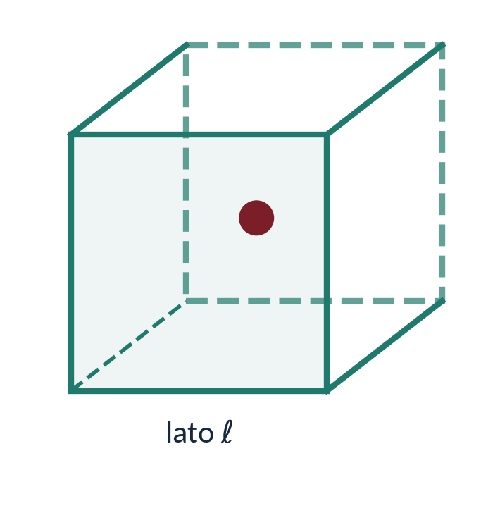

Estensione

## E se la superficie non è chiusa?

Gauss parla di superfici **chiuse**. Ma serve anche per quelle **aperte**:

1

Chiudila

aggiungi una superficie inventata da te

2

Applica Gauss al totale

flusso totale = carica dentro / ε<sub>0</sub>

3

Togli la parte inventata

quello che resta è il flusso che cercavi

Scegli la chiusura in modo che la parte inventata sia facile da calcolare.

Parte 2 · il metodo

## La gaussiana giusta

Gauss si usa bene quando la superficie è fatta di facce **perpendicolari (⟂)** (flusso E·A) o **parallele (∥)** (flusso 0) al campo.

[figure not shown]

La simmetria dice com'è E; la gaussiana si sceglie di conseguenza.

Simmetria sferica

## Sfera · La simmetria dà la forma di E

Sorgente a simmetria sferica: una rotazione attorno al centro la lascia identica.

- E è **radiale**.
- E ha lo stesso modulo a distanza r.

E(r)\cdot 4\pi r^2=\frac{Q_{\mathrm{int}}(r)}{\varepsilon_0}\ \Rightarrow\ E(r)=\frac{Q_{\mathrm{int}}(r)}{4\pi\varepsilon_0\,r^2}

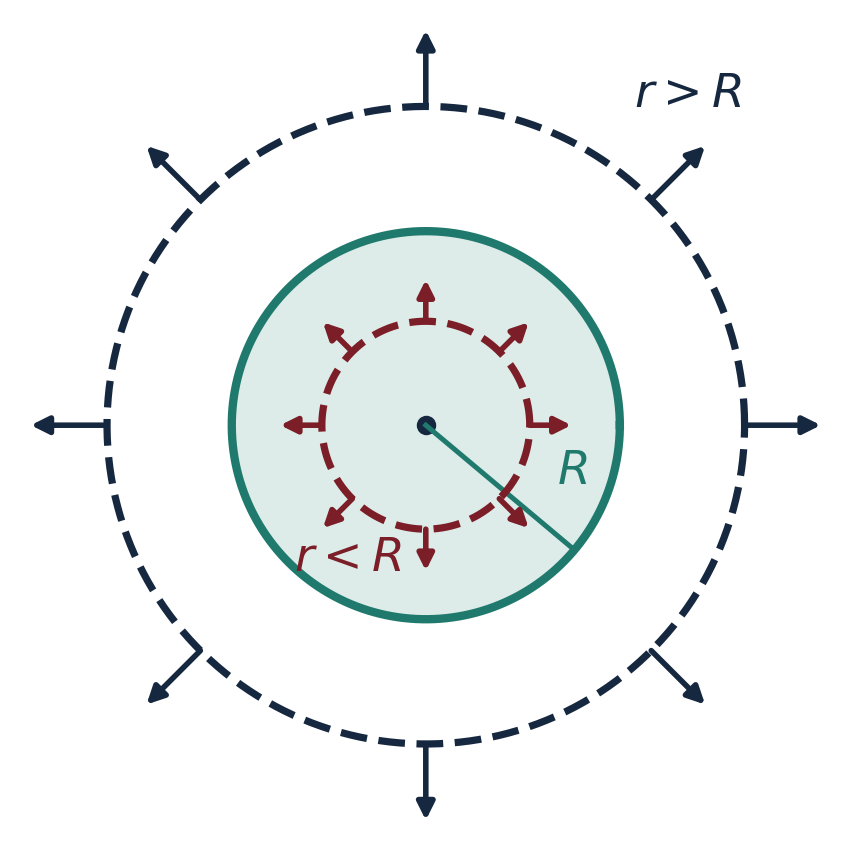

La sfera concentrica di raggio r è la superficie gaussiana giusta.

Simmetria cilindrica (1/2)

## Filo infinito · La simmetria

Filo infinito con **densità lineare di carica** λ (linear charge density, C/m).

- **Lungo il filo: nulla.** Le cariche a +z e −z hanno componenti lungo il filo che si cancellano.
- **Attorno al filo: nulla.** Lo specchio che contiene il filo e P non cambia nulla.
- **Il modulo dipende solo da d.** Traslazioni e rotazioni attorno al filo lo lasciano identico.

E è radiale e vale E(d).

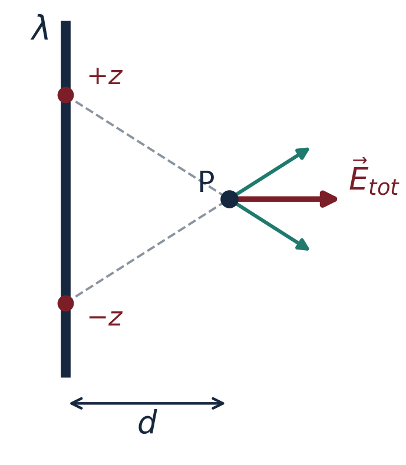

Simmetria cilindrica · il perché

## Filo infinito · Perché proprio un cilindro?

Sappiamo com'è E: esce dal filo in orizzontale, uguale tutt'intorno a distanza d. Quale superficie lo segue?

[figure not shown]

Il cilindro è la forma che il campo disegna da solo.

Simmetria cilindrica (2/2)

## Filo infinito · Gauss con un cilindro

**Gaussiana:** cilindro coassiale, raggio d, lunghezza L.

- Laterale: Φ = E·2πdL
- Basi: Φ = 0 (E parallelo alle basi)
- Carica: Q<sub>int</sub> = λL

E\cdot 2\pi d\,L=\frac{\lambda L}{\varepsilon_0}\ \Rightarrow\ E(d)=\frac{\lambda}{2\pi\varepsilon_0\,d}=\frac{2k\lambda}{d}

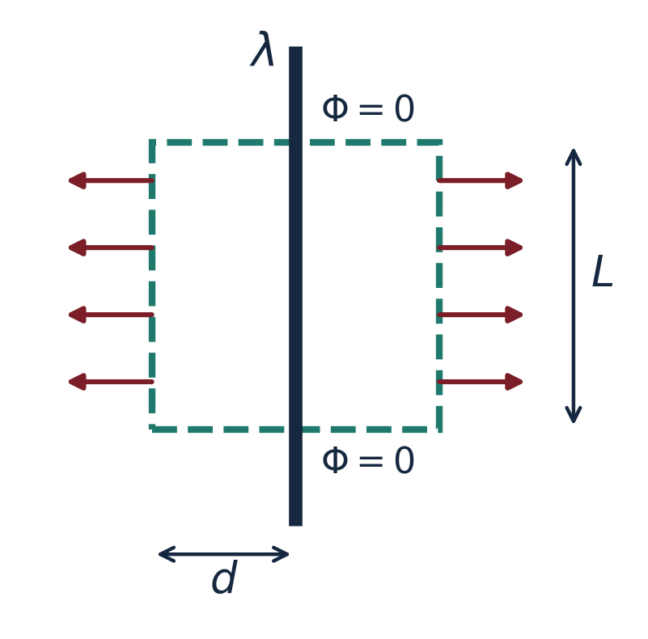

Filo

## Filo infinito · Come leggerlo

La lunghezza L **si semplifica**: il campo non dipende da quanto è lungo il cilindro.

E cala come **1/d**: le linee di forza si aprono in un solo piano, sulla circonferenza 2πd, non su una sfera.

Più superficie su cui si aprono le linee, meno campo.

Simmetria piana (1/2)

## Piano infinito · La simmetria

Piano infinito con **densità superficiale** σ (surface charge density, C/m²).

- **Perpendicolare al piano:** le componenti parallele si annullano.
- **Solo da d:** spostarsi lungo il piano non cambia nulla.
- **Lati opposti:** stesso modulo, verso opposto (si allontana da entrambi se σ > 0).

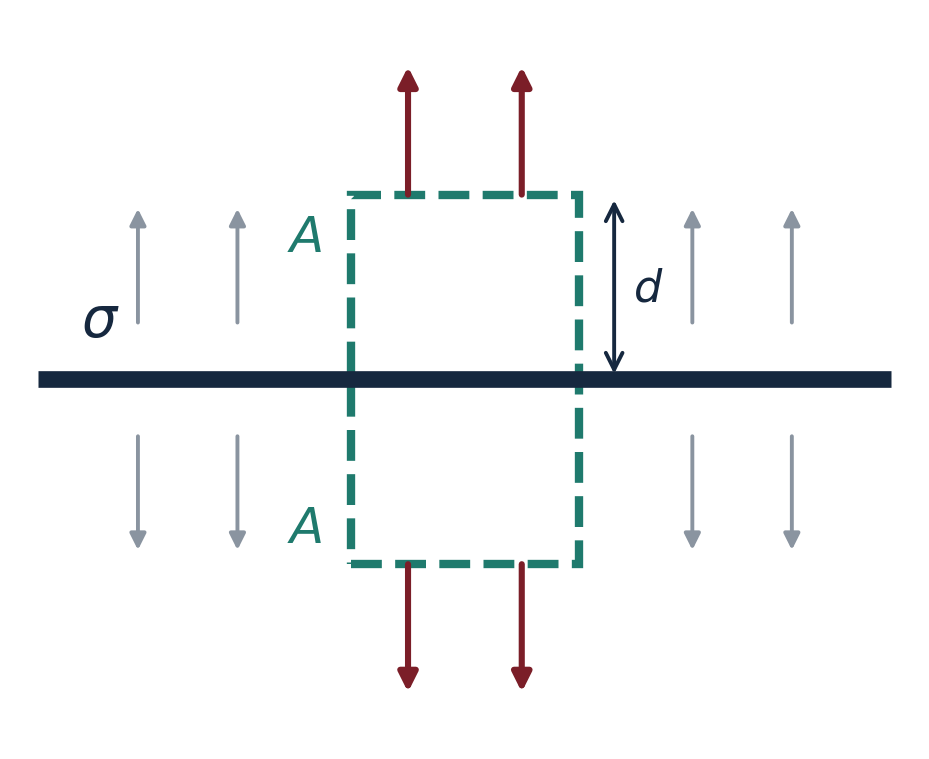

Simmetria piana · il perché

## Piano infinito · Perché una scatola?

Sappiamo com'è E: esce dal piano in verticale, da entrambe le parti, uguale a ogni quota. Quale superficie lo segue?

[figure not shown]

Una base per lato, parallele al piano: stesso E, flusso 2EA.

Simmetria piana (2/2)

## Piano infinito · Gauss con una scatola

**Gaussiana:** scatola con due basi di area A, ai due lati del piano, a distanza d.

- Basi: Φ = 2EA
- Laterale: Φ = 0
- Carica: Q<sub>int</sub> = σA

2EA=\frac{\sigma A}{\varepsilon_0}\ \Rightarrow\ E=\frac{\sigma}{2\varepsilon_0}

A si semplifica: E non dipende da d.

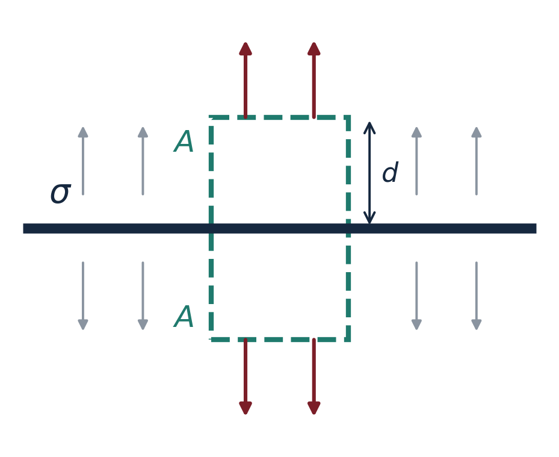

Perché 1/d, costante, 1/r²

## Tre geometrie, tre andamenti

- **Sfera:** le linee si aprono su 4πr²: E ∝ 1/r²
- **Filo:** si aprono sulla circonferenza 2πd: E ∝ 1/d
- **Piano:** restano parallele: E costante

L'esponente conta le dimensioni su cui le linee di forza si aprono.

Tre geometrie, tre andamenti

## E in funzione della distanza

Come leggerle

**Sfera, 1/r²**  
le linee si aprono su una sfera: il campo cala **in fretta**

**Filo, 1/d**  
si aprono su un cerchio: cala **più piano**

**Piano, costante**  
restano parallele: **non cala**

Sfera uniforme · il perché

## Sfera uniforme · Che carica racchiude la gaussiana?

La sfera è carica in tutto il volume. La gaussiana è sempre una sfera concentrica: cambia la carica che ha dentro.

Dentro racchiude solo la frazione (r/R)³ della carica.

Sfera (fuori)

## Sfera uniforme · Fuori: r > R

Sfera isolante di raggio R, carica Q uniforme nel volume. Superficie gaussiana: sfera concentrica di raggio **r > R**: dentro c'è tutta la carica, Q<sub>int</sub> = Q.

E\cdot 4\pi r^2=\frac{Q}{\varepsilon_0}\ \Rightarrow\ E(r)=\frac{Q}{4\pi\varepsilon_0\,r^2}

Fuori, il campo è quello di una carica puntiforme Q nel centro.

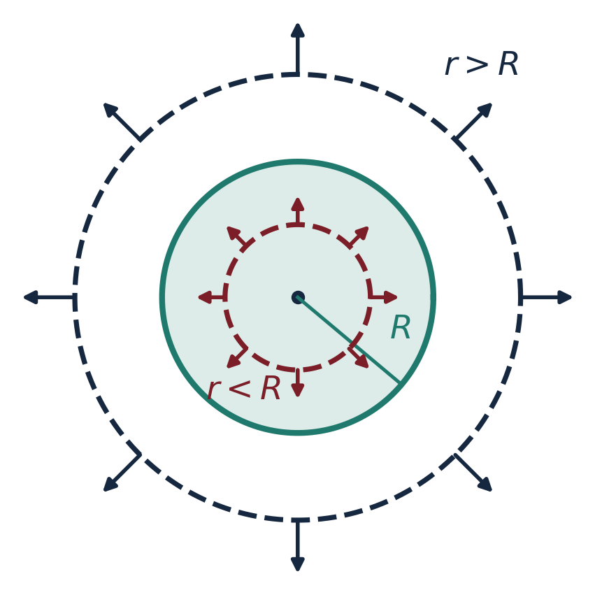

Sfera (dentro)

## Sfera uniforme · Dentro: r < R

Gaussiana: sfera concentrica di raggio **r < R**. Racchiude solo una parte della carica.

Q_{\mathrm{int}}=Q\,\frac{r^3}{R^3}

E\cdot4\pi r^2=\frac{Q\,r^3}{\varepsilon_0R^3}\ \Rightarrow\ E(r)=\frac{Q\,r}{4\pi\varepsilon_0R^3}

Carica ∝ r³, area ∝ r²: dentro il campo cresce come r.

Il profilo di E(r)

## Sfera uniforme: cambia il raggio R

Raccordo

**Dentro** (r < R)  
E **cresce** con r

**Fuori** (r > R)  
E **cala** come 1/r²

In **r = R** le due curve si incontrano: lì il campo è massimo

Esercizio svolto · impostazione

## Esercizio 1 · Filo carico

Filo molto lungo con densità lineare di carica λ = 2,0 nC/m. Calcola il campo a d<sub>1</sub> = 0,10 m e a d<sub>2</sub> = 0,30 m, e la forza su un protone a d<sub>1</sub>.

- Simmetria cilindrica: E radiale, modulo E(d).
- Superficie gaussiana: cilindro coassiale.
- Dalla slide del filo: E(d) = λ/(2πε<sub>0</sub>d) = 2kλ/d.

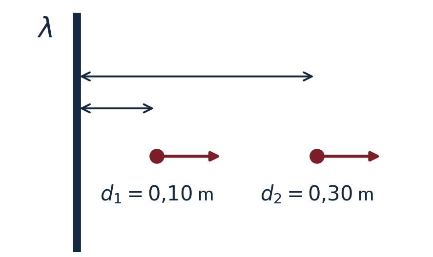

Esercizio svolto · calcolo

## Esercizio 1 · Calcolo

1

E(d_1)=\frac{2\cdot8{,}99\times10^{9}\cdot2{,}0\times10^{-9}}{0{,}10}=3{,}60\times10^{2}\ \mathrm{N/C}

campo a 0,10 m

2

E(d_2)=\frac{2\cdot8{,}99\times10^{9}\cdot2{,}0\times10^{-9}}{0{,}30}=1{,}20\times10^{2}\ \mathrm{N/C}

distanza ×3 ⇒ campo ÷3, coerente con 1/d

3

F=eE=1{,}602\times10^{-19}\cdot3{,}60\times10^{2}=5{,}76\times10^{-17}\ \mathrm{N}

verso l'esterno (λ positivo)

Errori tipici e controlli

- Dimenticare il 2: 180 N/C
- Usare 1/d²: kλ/d² = 1,80×10³ N/C, oppure E(d<sub>2</sub>) = E(d<sub>1</sub>)/9 = 40,0 N/C

Esercizio svolto · impostazione

## Esercizio 2 · Due piani paralleli

Due piani molto estesi con densità di carica +σ e −σ, con σ = 2,0 μC/m². Trova E fra i piani e fuori. Ripeti con due cariche dello stesso segno. Forza su un elettrone fra i piani.

- Prima il campo di **un** piano (Gauss, scatola).
- Poi la **sovrapposizione**: somma vettoriale dei due campi.
- Fra i piani i campi hanno lo stesso verso, fuori verso opposto.

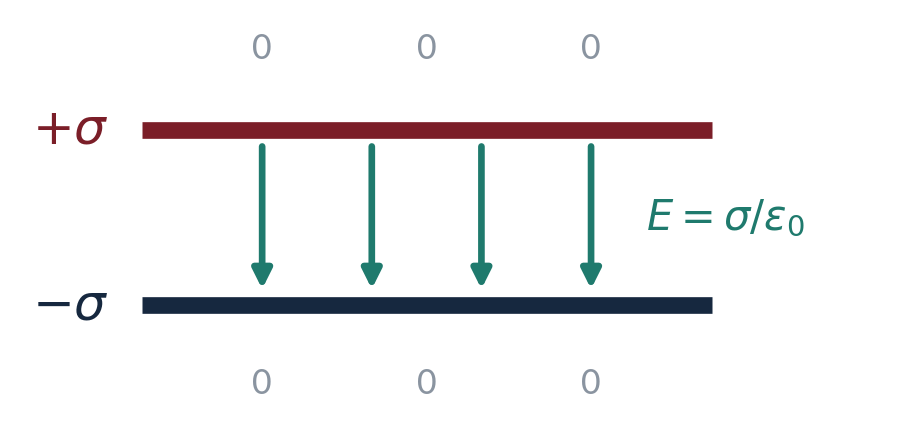

Esercizio svolto · calcolo

## Esercizio 2 · Calcolo

1

E_1=\frac{\sigma}{2\varepsilon_0}=\frac{2{,}0\times10^{-6}}{2\cdot8{,}85\times10^{-12}}=1{,}13\times10^{5}\ \mathrm{N/C}

campo di un piano solo

2

E_{\mathrm{fra}}=2E_1=2{,}26\times10^{5}\ \mathrm{N/C}\qquad E_{\mathrm{fuori}}=0

segni opposti: fra i piani si somma, fuori si sottrae. Forza su un elettrone fra i piani: F = eE = 3,62×10⁻¹⁴ N

3

\text{stesso segno:}\ E_{\mathrm{fuori}}=2E_1=2{,}26\times10^{5}\ \mathrm{N/C}\qquad E_{\mathrm{fra}}=0

cariche uguali: fuori i campi si sommano, in mezzo si annullano

Errori tipici e controlli

- Usare σ/ε<sub>0</sub> per ogni piano e sommare: 4,52×10⁵ N/C
- Dimenticare che fuori si annulla, o sommare invece di sottrarre con segni uguali

Esercizio svolto · impostazione

## Esercizio 3 · Sfera uniformemente carica

Sfera isolante con carica Q = 6,0 μC distribuita in modo uniforme, raggio R = 0,20 m. Calcola E a r = 0,10 m, r = 0,20 m, r = 0,40 m.

- Simmetria sferica: gaussiana = sfera concentrica.
- Dentro (r < R): E = kQr/R³. Fuori (r > R): E = kQ/r².
- In r = R le due formule devono coincidere: controllo.

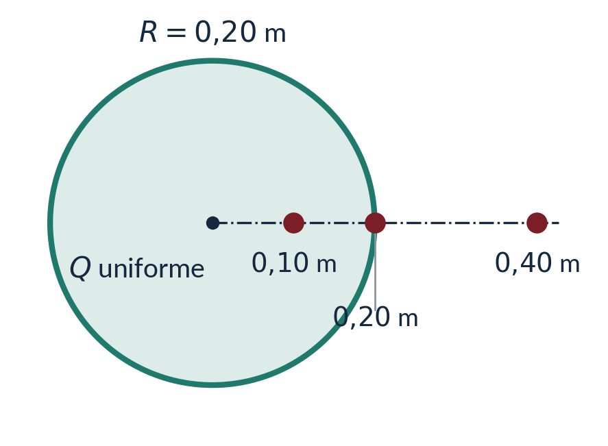

Esercizio svolto · calcolo

## Esercizio 3 · Calcolo

1

r=0{,}10\ \mathrm{m}\lt R:\quad E=\frac{kQ\,r}{R^3}=\frac{8{,}99\times10^{9}\cdot6{,}0\times10^{-6}\cdot0{,}10}{(0{,}20)^3}=6{,}74\times10^{5}\ \mathrm{N/C}

dentro: la carica racchiusa cresce come r³

2

r=R:\quad E=\frac{kQ}{R^2}=1{,}35\times10^{6}\ \mathrm{N/C}

sulla superficie le due formule coincidono

3

r=0{,}40\ \mathrm{m}=2R:\quad E=\frac{kQ}{r^2}=3{,}37\times10^{5}\ \mathrm{N/C}=\frac{E(R)}{4}

fuori; controllo E(R/2) = E(R)/2

Errori tipici e controlli

- Coulomb dentro: kQ/r² = 5,39×10⁶ N/C (4 volte E(R))
- Un ottavo di E(R): 1,69×10⁵ N/C. Campo nullo dentro: 0